# IODS course project

To observe the consistency with which some individuals score higher on the bprs, regardless of the time of the measurement, it is advisable to standardize with respect to the weekly measurement values. Since we have some zigg-zagging and an overall declining trend to the measurement values, this allows us to better observe the individual measurement value comparative to the average value of that week.

```r
library(dplyr)
library(tidyr)

# Standardise the variable bprs
BPRSL <- BPRSL %>%
  group_by(week) %>%
  mutate(stdbprs = scale(bprs)) %>%
  ungroup()

# Glimpse the data
glimpse(BPRSL)
```

```
## Rows: 360
## Columns: 6
## $ treatment <fct> 1, 1, 1, 1, 1, 1, 1, 1, 1, 1, 1, 1, 1, 1, 1, 1, 1, 1, 1, 1, ~
## $ subject   <fct> 1, 2, 3, 4, 5, 6, 7, 8, 9, 10, 11, 12, 13, 14, 15, 16, 17, 1~
## $ weeks     <chr> "week0", "week0", "week0", "week0", "week0", "week0", "week0~
## $ bprs      <dbl> 42, 58, 54, 55, 72, 48, 71, 30, 41, 57, 30, 55, 36, 38, 66, ~
## $ week      <dbl> 0, 0, 0, 0, 0, 0, 0, 0, 0, 0, 0, 0, 0, 0, 0, 0, 0, 0, 0, 0, ~
## $ stdbprs   <dbl[,1]> <matrix[26 x 1]>
```

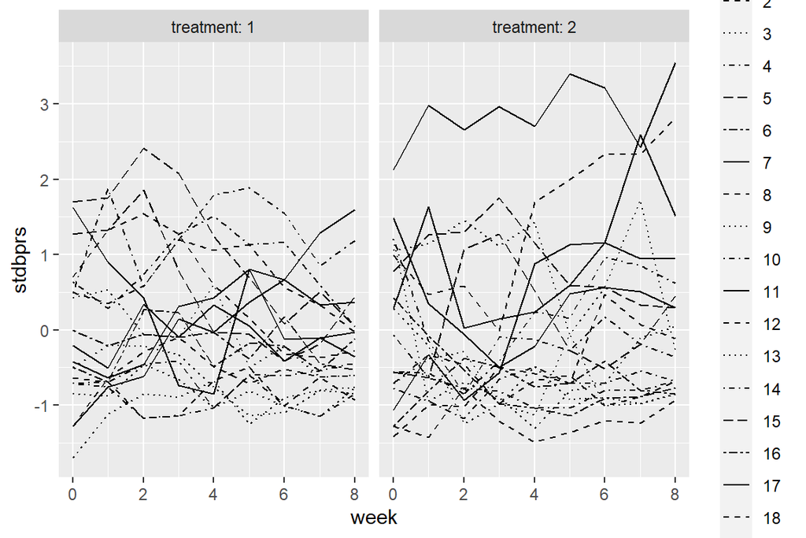

```r
# Plot again with the standardised bprs
library(ggplot2)
ggplot(BPRSL, aes(x = week, y = stdbprs, linetype = subject)) +
  geom_line() +
  scale_linetype_manual(values = rep(1:10, times=4)) +
  facet_grid(. ~ treatment, labeller = label_both) +
  scale_y_continuous(name = "stdbprs")
```

There is some zigg-zagging (unlike with the weights of the rats), so that the rank of the individual in terms of his BPRS-value is not constant through time, but there is considerable consistency in the rank.

Now we could continue neglecting the correlational structure imposed by the repetitive nature of our measurements and explore the association between the treatment and the primary outcome with simple regression analysis, as follows:

```r
# Create a regression model for BPRS
BPRS_reg <- lm(bprs ~ week + treatment, data=BPRSL)

# print out a summary of the model
summary(BPRS_reg)
```

```
##
## Call:
## lm(formula = bprs ~ week + treatment, data = BPRSL)
##
## Residuals:
##     Min      1Q  Median      3Q     Max
## -22.454  -8.965  -3.196   7.002  50.244
##
## Coefficients:
##             Estimate Std. Error t value Pr(>|t|)
## (Intercept)  46.4539     1.3670  33.982   <2e-16 ***
## week         -2.2704     0.2524  -8.995   <2e-16 ***
## treatment2    0.5722     1.3034   0.439    0.661
## ---
## Signif. codes:  0 '***' 0.001 '**' 0.01 '*' 0.05 '.' 0.1 ' ' 1
##
## Residual standard error: 12.37 on 357 degrees of freedom
## Multiple R-squared:  0.1851, Adjusted R-squared:  0.1806
## F-statistic: 40.55 on 2 and 357 DF,  p-value: < 2.2e-16
```

and we could note that while the regression coefficient estimate for the week is negative and highly significant, the treatment dummy is not (when conditioning on the week). But such analysis would neglect the inherent structure of our data by assuming there to exist no within-subject correlation between the repetitive measurements.

A more meaningful analysis is based on linear mixed effects models, that allow for random effects for either the intercept or the coefficients (“mixed”) or both (“full random-effecta”) as opposed to treating these all as fixed. This means that one may account for the fact that the intercept terms differ by individual (them being thought of as sampled from a normal distribution with mean zero and a variance reflecting the across-individuals variability of the intercepts); and, further, that also the regression coefficients (for the explanatory time variable) ought allowed to so differ. Both of the intercepts and the coefficients can then be considered to have shared as well as individual-specific terms, with the random intercepts providing the individual discrepancy from the shared term for the intercept, and the random coefficients the individual discrepancy from the shared term for the slope.

```r
# access library lme4
library(lme4)
# Create a random intercept model
BPRS_ref <- lmer(bprs ~ week + treatment + (1 | subject), data = BPRSL, REML = FALSE)

# Print the summary of the model
summary(BPRS_ref)
```

```
## Linear mixed model fit by maximum likelihood  ['lmerMod']
## Formula: bprs ~ week + treatment + (1 | subject)
##    Data: BPRSL
##
##      AIC      BIC   logLik deviance df.resid
##   2748.7   2768.1  -1369.4   2738.7      355
##
## Scaled residuals:
##     Min      1Q  Median      3Q     Max
## -3.0481 -0.6749 -0.1361  0.4813  3.4855
##
## Random effects:
##  Groups   Name        Variance Std.Dev.
##  subject  (Intercept)  47.41    6.885
##  Residual             104.21   10.208
## Number of obs: 360, groups:  subject, 20
##
## Fixed effects:
##             Estimate Std. Error t value
## (Intercept)  46.4539     1.9090  24.334
## week         -2.2704     0.2084 -10.896
## treatment2    0.5722     1.0761   0.532
##
## Correlation of Fixed Effects:
##            (Intr) week
## week       -0.437
## treatment2 -0.282  0.000
```

We may note that our random effects are in place, with the variability of the intercepts across the individuals comparatively high, at an estimated variance of roughly 47 (with the range of our outcome from 18 to 95). Our shared and fixed treatment term has a t-value of 0.53, which is clearly not statistically significant. Our best fixed effect estimate for the regression coefficient of the week remains as before, with a point estimate roughly at -2.3.

We should allow for individually varying slopes, so let us fit a model with both random intercept as well as random regression coefficient for the week. We can then compare which model better fits the data, with our a priori assumption being that the fully random trumps the mixed model (with fixed slope).

```r
# Create a random intercept and random slope model
library(lme4)

BPRS_ref1 <- lmer(bprs ~ week + treatment + (week | subject), data = BPRSL, REML = FALSE)

# print a summary of the model
summary(BPRS_ref1)
```

```
## Linear mixed model fit by maximum likelihood  ['lmerMod']
## Formula: bprs ~ week + treatment + (week | subject)
##    Data: BPRSL
##
##      AIC      BIC   logLik deviance df.resid
##   2745.4   2772.6  -1365.7   2731.4      353
##
## Scaled residuals:
##     Min      1Q  Median      3Q     Max
## -2.8919 -0.6194 -0.0691  0.5531  3.7976
##
## Random effects:
##  Groups   Name        Variance Std.Dev. Corr
##  subject  (Intercept) 64.8222  8.0512
##           week         0.9609  0.9802   -0.51
##  Residual             97.4305  9.8707
## Number of obs: 360, groups:  subject, 20
##
## Fixed effects:
##             Estimate Std. Error t value
## (Intercept)  46.4539     2.1052  22.066
## week         -2.2704     0.2977  -7.626
## treatment2    0.5722     1.0405   0.550
##
## Correlation of Fixed Effects:
##            (Intr) week
## week       -0.582
## treatment2 -0.247  0.000
```

```r
# perform an ANOVA test on the two models
anova(BPRS_ref1, BPRS_ref)
```

```
## Data: BPRSL
## Models:
## BPRS_ref: bprs ~ week + treatment + (1 | subject)
## BPRS_ref1: bprs ~ week + treatment + (week | subject)
##           npar    AIC    BIC  logLik deviance  Chisq Df Pr(>Chisq)
## BPRS_ref     5 2748.7 2768.1 -1369.4   2738.7
## BPRS_ref1    7 2745.4 2772.6 -1365.7   2731.4 7.2721  2    0.02636 *
## ---
## Signif. codes:  0 '***' 0.001 '**' 0.01 '*' 0.05 '.' 0.1 ' ' 1
```

We may wrap up our modeling by looking at a random effects model that includes an interaction term between the treatment and the week.

```r
# Create a random intercept and random slope model with the interaction
library(lme4)
BPRS_ref2 <-  lmer(bprs ~ week * treatment + (week | subject), data = BPRSL, REML = FALSE)

# print a summary of the model
summary(BPRS_ref2)
```

```
## Linear mixed model fit by maximum likelihood  ['lmerMod']
## Formula: bprs ~ week * treatment + (week | subject)
##    Data: BPRSL
##
##      AIC      BIC   logLik deviance df.resid
##   2744.3   2775.4  -1364.1   2728.3      352
##
## Scaled residuals:
##     Min      1Q  Median      3Q     Max
## -3.0512 -0.6271 -0.0768  0.5288  3.9260
##
## Random effects:
##  Groups   Name        Variance Std.Dev. Corr
##  subject  (Intercept) 64.9964  8.0620
##           week         0.9687  0.9842   -0.51
##  Residual             96.4707  9.8220
## Number of obs: 360, groups:  subject, 20
##
## Fixed effects:
##                 Estimate Std. Error t value
## (Intercept)      47.8856     2.2521  21.262
## week             -2.6283     0.3589  -7.323
## treatment2       -2.2911     1.9090  -1.200
## week:treatment2   0.7158     0.4010   1.785
##
## Correlation of Fixed Effects:
##             (Intr) week   trtmn2
## week        -0.650
## treatment2  -0.424  0.469
## wek:trtmnt2  0.356 -0.559 -0.840
```

```r
# perform an ANOVA test on the two models
anova(BPRS_ref2, BPRS_ref1)
```

```
## Data: BPRSL
## Models:
## BPRS_ref1: bprs ~ week + treatment + (week | subject)
## BPRS_ref2: bprs ~ week * treatment + (week | subject)
##           npar    AIC    BIC  logLik deviance  Chisq Df Pr(>Chisq)
## BPRS_ref1    7 2745.4 2772.6 -1365.7   2731.4
## BPRS_ref2    8 2744.3 2775.4 -1364.1   2728.3 3.1712  1    0.07495 .
## ---
## Signif. codes:  0 '***' 0.001 '**' 0.01 '*' 0.05 '.' 0.1 ' ' 1
```

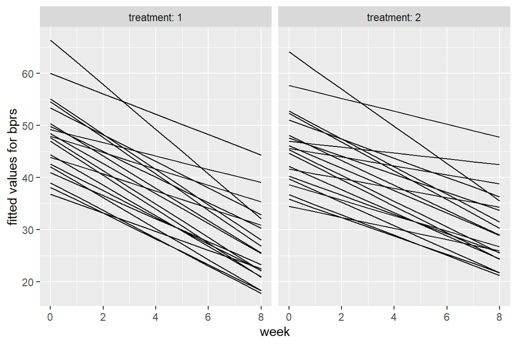

```r
# Create a vector of the fitted values
Fitted <- fitted(BPRS_ref2)

library(dplyr)
library(tidyr)

# Create a new column fitted to BPRSL
BPRSL <- mutate(BPRSL,fitted=Fitted)

# draw the plot of BPRS with the Fitted values of bprs
library(ggplot2)
ggplot(BPRSL, aes(x = week, y = fitted, group = subject)) +
  geom_line() +
  scale_linetype_manual(values = rep(1:10, times=4)) +
  facet_grid(. ~ treatment, labeller = label_both) +
  scale_y_continuous(name = "fitted values for bprs")
```

We may note that while our other estimates remain roughly where they were in terms of their magnitude and direction, we have an interaction that is borderline statistically significant in terms of the two-sided test (with a point estimate at 0.7 and standard error of 0.4). The likelihood-ratio test between the full random effect model with and without an interaction provides a chi-square test statistic of 3.17 in favor of the interaction model with one degree of freedom (the interaction term), which is associated with a p-value of 0.08. This is suggestive of the interaction model providing the better fit with the data at hand, but this is both a borderline, as well as a judgement call in general. For instance, we may note that the BIC is a tad higher for our interaction model, since this measure of fit penalizes for the additional complexity that comes with the inclusion of the interaction term.

Overall, in terms of the comparison of the treatments when it comes to their efficacy measured with the BPRS, we may conclude that our data is compatible with the null of equal efficacy of the two treatments.

Finally, by looking at the fitted values of the random effects interaction model, we may observe that our point estimates for the BPRS-values within the followup period are very similar across the two treatments. This bolsters our conclusion that there are no substantively meaningful differences between the two assessed treatments in terms of their efficacy in reducing psychiatric symptoms when measured by the BPRS during a two-month followup period.